# Reuters Corpus NLP Models Comparison

```python
import pandas as pd

df = pd.DataFrame(bam_pmiMat_tr100)
df.head() #testing whether the dimensionality reduction worked
```

|  | 0 | 1 | 2 | 3 | 4 | 5 | 6 | 7 | 8 | 9 | ... | 90 | 91 | 92 | 93 | 94 | 95 | 96 | 97 | 98 | 99 |
| --- | --- | --- | --- | --- | --- | --- | --- | --- | --- | --- | --- | --- | --- | --- | --- | --- | --- | --- | --- | --- | --- |
| 0 | 3.194642 | -3.386466 | 1.660963 | -0.157119 | -0.344277 | -2.041355 | -2.406770 | 3.393222 | 0.156607 | 1.164507 | ... | -0.617149 | 0.301465 | -1.942431 | 1.623465 | -3.155962 | -0.804169 | -1.129561 | 0.016953 | -0.346338 | -0.769266 |
| 1 | 2.254858 | -3.281891 | -1.946499 | -0.632289 | 1.622752 | -0.286314 | 1.048640 | -0.891976 | 0.844589 | 0.097819 | ... | -0.006516 | -0.083870 | 0.097036 | -0.556158 | -0.288065 | -0.299552 | -0.196025 | -0.042958 | 0.204430 | -0.010254 |
| 2 | 2.685616 | -2.784519 | -0.768807 | -1.419688 | 1.424648 | 0.030763 | 1.089219 | 0.597931 | -1.389571 | 0.618430 | ... | -0.918921 | -0.245293 | 0.243757 | -1.753950 | 0.755330 | -1.309378 | 0.116999 | -0.187859 | 2.464734 | -1.832003 |
| 3 | 1.686459 | -5.120653 | 0.368789 | -1.388233 | 0.367869 | -3.306106 | 4.297130 | 6.312591 | -1.061373 | -5.747439 | ... | 2.077071 | -0.777115 | 0.861538 | 0.586031 | -0.776339 | 0.917926 | 1.369127 | -0.051235 | 0.477402 | -1.168615 |
| 4 | 1.271012 | -2.679362 | -1.983844 | -0.028687 | -0.421057 | -1.117206 | 0.580466 | -0.648277 | 2.296424 | -0.048959 | ... | -0.724715 | -0.336736 | -0.036941 | 0.086073 | 0.967188 | -0.425747 | 0.133161 | -0.613224 | 0.487695 | -1.448410 |

5 rows × 100 columns

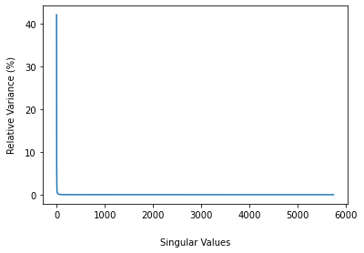

```python
from scipy import linalg, dot

U, s, Vt = linalg.svd(plmiMat)

# Ignoring Vt

rel_variance = ( s**2 / sum(s**2) ) * 100
y_values = rel_variance
x_values = np.arange(len(y_values))

plt.plot(x_values, y_values, linestyle = '-')

plt.xlabel("Singular Values", labelpad = 20)
plt.ylabel("Relative Variance (%)", labelpad = 10)

plt.show()
```

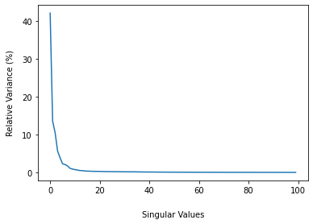

```python
y_values =  rel_variance[:100]
x_values = np.arange(len(y_values))

plt.plot(x_values, y_values, linestyle = '-')

plt.xlabel("Singular Values", labelpad = 20)
plt.ylabel("Relative Variance (%)", labelpad = 10)

plt.show()
```

```python
dimensions = 20 #based on the scree plot my dimension should be around 10-30.
                #However, if I run this model through the evaluation it gives a very low rating.
W = U[:, 0 : dimensions]
sigma = s[:dimensions]
C = Vt[0 : dimensions, :]

ppmiMat_tr50 = np.dot(W, linalg.diagsvd(sigma, dimensions, len(C)))

df = pd.DataFrame(ppmiMat_tr50)
df.head() #testing whether the dimensionality reduction worked
```

|  | 0 | 1 | 2 | 3 | 4 | 5 | 6 | 7 | 8 | 9 | 10 | 11 | 12 | 13 | 14 | 15 | 16 | 17 | 18 | 19 |
| --- | --- | --- | --- | --- | --- | --- | --- | --- | --- | --- | --- | --- | --- | --- | --- | --- | --- | --- | --- | --- |
| 0 | -0.587908 | -1.272614 | -0.198519 | 0.081219 | -1.049819 | 0.736354 | 0.069094 | -0.453199 | -0.576162 | -0.512187 | -1.467671 | 0.782910 | 0.323586 | 0.003936 | 1.171713 | -1.153777 | 0.700813 | -0.535616 | 1.964134 | 2.588341 |
| 1 | -5.275384 | -1.204054 | -5.424600 | -1.657403 | -5.250083 | 0.368037 | -4.537820 | 0.113680 | -2.490579 | -0.870463 | -0.572572 | -0.031532 | -1.362388 | -2.425559 | -2.628291 | -0.193583 | -0.937371 | 0.371874 | -0.208500 | -0.281547 |
| 2 | -2.829349 | -1.802252 | -1.242229 | 1.592211 | -0.781203 | 1.992597 | 0.857040 | 2.066856 | 2.363373 | 4.001642 | -1.581244 | -1.899431 | -0.815302 | -0.457203 | -1.534899 | -2.369593 | -0.845788 | -0.606614 | 0.083525 | 1.730319 |
| 3 | -13.816831 | 9.212942 | -5.407005 | -0.653507 | -3.859685 | 2.802605 | 14.511081 | 0.981600 | 0.319992 | -1.251823 | 0.526329 | 4.838886 | -0.932805 | -1.001713 | 1.562075 | 0.709313 | 4.847704 | -1.968050 | -0.956977 | 3.116242 |
| 4 | -0.924849 | -3.366784 | -0.962595 | -2.181574 | -4.369975 | 1.435332 | 0.083679 | -0.793145 | -2.169962 | -0.576782 | -1.547163 | -0.491965 | -0.853832 | -1.149386 | 0.239273 | 0.183790 | -0.357896 | -0.145645 | -0.031924 | 0.582959 |

Train a Word2Vec model on the same corpus, for example using gensim. Make sure to motivate the choice of your hyperparameters.

*Fine-tuning* is the process of starting from a pre-trained embedding model and training it some more using new data. Try to use a pre-trained model from gensim and to fine-tune it on the Reuters corpus.

```python
import gensim.models
listofsentences = []
for sentence in reuters_lemmatized: #create list of lemmatized sentences to feed into model
    line = []
    for word in sentence:
        line.append(word.split("-")[0])
    listofsentences.append(line)
```

```python
from gensim.models import Word2Vec, KeyedVectors

# Using params from Word2Vec_FastText_Comparison
params = {
    'size': 100, # for now I will be using 100 dimensions of embeddings as I want to fairly compare it with my other models
    'window': 5, # window -/+ before and after focus word as in question 1
    'iter': 5, # number of iterations over the corpus
    'min_count': 5, # filter on words whose frequency is below this count
    'sg': 1, #I tried both CBOW and SG and found the SG to report better results.
    'negative': 5, # no changes.
    'workers': 4, # no changes.
    'alpha': 0.12 # initial learning rate for SGD. I saw that I could tweak it to perform better on the test. It still performs well with alpha of 0.05.
}
model = Word2Vec(listofsentences, **params)
print(model)
```

```
Word2Vec(vocab=7803, size=100, alpha=0.12)
```

```python
#training my own model

from gensim.models import Word2Vec
from gensim.models import KeyedVectors
import gensim.downloader as api

model1 = api.load("glove-wiki-gigaword-100") #load original
model1.save_word2vec_format('gwg100.txt', binary=False) #save in txt format

model2 = Word2Vec(size=100, min_count=1)
model2.build_vocab(listofsentences) #build with original sentences
total_examples = model2.corpus_count

model2.build_vocab([list(model1.vocab.keys())], update=True) #build with vocab from model1
model2.intersect_word2vec_format('gwg100.txt', binary=False, lockf=1.0) #intersecting the two vocabs
model2.train(listofsentences, total_examples=total_examples, epochs=model2.iter)

print(model2)

"""inspired by: "https://datascience.stackexchange.com/questions/10695/how-to-initialize-a-new-word2vec-model-with-pre-trained-model-weights"""
```

```
Word2Vec(vocab=404809, size=100, alpha=0.025)
```

```
'inspired by: "https://datascience.stackexchange.com/questions/10695/how-to-initialize-a-new-word2vec-model-with-pre-trained-model-weights'
```

# Evaluating on semantic similarity

Evaluate the performance of your models on a **semantic similarity task**. Using `SimLex-999` as gold standard. Evaluate all of your models on the dataset in `data/SimLex-999.txt`, and determine the best performing model. Note: There should be 5 to 8 model evaluations in total. 5 if you did not do any extra (2 from 4.1 + 2 from 4.2 + 1 from 4.3), and 8 if you did them all (3 from 4.1 + 3 from 4.2 + 2 from 4.3).

1. Your evaluation should follow the approach shown in lab 4 (Section 1.6: "Evaluating your Model"), using a **correlation measure** on model predictions and the (human) gold standard.
2. Remember to **visualize** your results (e.g., as bar plots).
3. Take note (and report) the overlap between your models and the SimLex-999 dataset, i.e., how many pairs are shared by your model and the evaluation dataset.
4. Make sure to discuss your results and provide your reasoning on them.

### Remarks

- The 'SimLex-999' dataset is described in `data/SimLex-999.README.txt`, and [the author's github page](https://fh295.github.io/simlex.html). Hint: the relevant judgements are those in the `SimLex999` column.
- To directly compare the models against the gold standard, you will have to find the *overlap* between them, i.e. the pairs that occur in your model *and* the evaluation dataset.

I begin my evaluation against a dictionary of nouns that overlap in both my vectors_indices and SimLex-999

```python
makinglists = []
for w, i in vectors_indices.items():
    makinglists.append(w.split("-")[0]) #making liss of only nouns without pos tag

simLex_999 = dict()

with open("data/SimLex-999.txt") as f:
    contents = f.read().split("\n")
    listofitems = []

    for n, line in enumerate(contents):
        items = line.split("\t")
        listofitems.append(items)
        if (listofitems[n][0] in makinglists and listofitems[n][1] in makinglists):
                w1 = items[0] + "-NOUN" #I chose to compare only nouns
                w2 = items[1] + "-NOUN"
                simLex_999[(w1, w2)] = float(listofitems[n][4])
```

```python
bam_pmiSimMat = sklearn.metrics.pairwise.cosine_similarity(bampmiMat)
plmiSimMat = sklearn.metrics.pairwise.cosine_similarity(plmiMat)
smoothppmiSimMat = sklearn.metrics.pairwise.cosine_similarity(smoothedppmiMat)

bam_pmitrunkSimMat = sklearn.metrics.pairwise.cosine_similarity(bam_pmiMat_tr100)
plmitrunkSimMat = sklearn.metrics.pairwise.cosine_similarity(plmiMat_tr100)
smoothppmitrunkSimMat = sklearn.metrics.pairwise.cosine_similarity(smoothedppmiMat_tr100)


measure2mat = {"BAM.PMI": bam_pmiSimMat, "positiveLMI": plmiSimMat, "BAM-tr100": bam_pmitrunkSimMat,
               "plmi-tr100" : plmitrunkSimMat, "sppmi" : plmitrunkSimMat, "sppmi-tr100" : smoothppmitrunkSimMat}

rhos = []
measures = []

for m, mat in measure2mat.items():

    wordSim_ratings = []
    vsm_sims = []
    for (w1, w2), r in simLex_999.items():
        w1idx = vectors_indices[w1]
        w2idx = vectors_indices[w2]

        wordSim_ratings.append(r)
        vsm_sims.append(mat[w1idx, w2idx])

    rho, pval = scipy.stats.spearmanr(wordSim_ratings, vsm_sims)

    rhos.append(rho)
    print(m, rho)
    measures.append(m)
```

```
BAM.PMI 0.11697473622685993
positiveLMI 0.06704802073997353
BAM-tr100 0.054009091341735316
plmi-tr100 0.04522664081160792
sppmi 0.04522664081160792
sppmi-tr100 0.06928226168221875
```

```python
wordSim_ratings = []
vsm_sims = []
counting = 0
for line in listofitems:
    if len(line) > 1:
        word1 = line[0]
        word2 = line[1]
        pos = line[2]
        value = line[3]

        if word1 in model.wv.vocab.keys() and word2 in model.wv.vocab.keys() and pos == "N":
            counting = counting + 1
            wordSim_ratings.append(float(value))
            vsm_sims.append(model.wv.similarity(word1, word2))


rho, pval = scipy.stats.spearmanr(wordSim_ratings, vsm_sims)
print("word2vec", rho)
rhos.append(rho)
measures.append("word2vec")
```

```
word2vec 0.2681620809829726
```

```python
wordSim_ratings = []
vsm_sims = []
counting2 = 0
for line in listofitems:
    if len(line) > 1:
        word1 = line[0]
        word2 = line[1]
        pos = line[2]
        value = line[3]

        if word1 in model2.wv.vocab.keys() and word2 in model2.wv.vocab.keys() and pos == "N":
            counting2 = counting2 + 1
            wordSim_ratings.append(float(value))
            vsm_sims.append(model2.wv.similarity(word1, word2))


rho, pval = scipy.stats.spearmanr(wordSim_ratings, vsm_sims)
print("pretrained word2vec", rho)
rhos.append(rho)
measures.append("word2vec2")
```

```
pretrained word2vec 0.2991772777162923
```

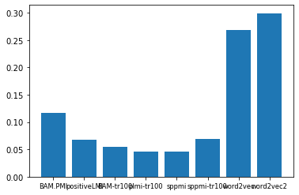

```python
plt.bar(range(0, len(rhos)), rhos)
plt.xticks(range(0, len(rhos)), measures, size='small')
plt.show()
```

It is explanable that PPMI and PLMI have a lower spearman score than PPMI and PLMI as they have lower dimensions, however, it seems off to me that PPMI is larger than PLMI as PLMI should add increased weighting to word-context pairs with higher frequency. Perhaps this has to do with the fact that this test is on nouns overlapping with initial vocab and not both word-context pairs.

On another note it seems off to me that the sppmi performs worse than bam.pmi as it should tackle PPMIs bias towards co- occurrences of rare words.

The Word2vec models clearly outperform the rest. Interestingly, whenever I re-run the notebook they perform differently, perhaps this is because the hidden layers create different weights everytime.

**3. Taking note of the overlap of word-context pairs:**

```python
print("number of word-context pairs in SimLex999:", len(listofitems)-1) #last line of file is empty
print("number of word-context pairs in origina list:", len(filtered_cooccs_surface.items()))
```

```
number of word-context pairs in SimLex999: 1000
number of word-context pairs in origina list: 1128854
```

```python
listofpairsmymodels = []
for i, x in filtered_cooccs_surface.items():
    tupln = (i[0].split("-")[0], i[1].split("-")[0])
    listofpairsmymodels.append(tupln)

listofpairsSimLex999 = []
for i, x in enumerate(listofitems[:-1]): #removing empty list at the end
    tupln = (listofitems[i][0], listofitems[i][1])
    listofpairsSimLex999.append(tupln)

counter = 0
for i in listofpairsSimLex999[1:]:
    if i in listofpairsmymodels:
        counter = counter + 1

print("There are", counter, "overlaps of word-context pairs between my original surface co-coocurences and SimLex999 word pairs")
```

```
There are 51 overlaps of word-context pairs between my original surface co-coocurences and SimLex999 word pairs
```

```python
print("number of words used for bam.pmi, plmi, sppmi, matrices rating:", len(simLex_999))
print("number of words used for word2vec rating:", counting)
print("number of words for word2vec:", counting2)
```

```
number of words used for bam.pmi, plmi, sppmi, matrices rating: 551
number of words used for word2vec rating: 232
number of words for word2vec: 666
```

**4. Discussion**

Since there are very few overlaps in comparison to the total number of pairs in the model PPMI and PLMI perform poorly. The dimensionality reduced versions of PPMI and PLMI perform worse as they do not seem to contain as much information, that can aid the final similarity score from the space. As expected Word2Vec Performs very well in comparison to all models.

**A word on filtering**

**Going further: testing the models with a dictionary of overlapping word context pairs**

Because the PPMI overvalues low frequencies words it is performs much better than PLMI if I do not remove low frequency words at the start. With prefilterting word-context pairs of less than 10 freq and words with freq less than 10 for dice method and performing the test only on overlaps of word context pairs I receive the following values:

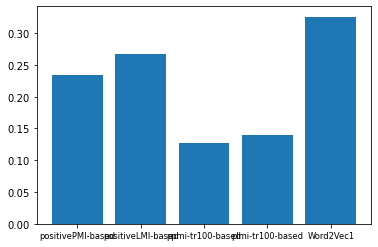

```python
rhos = [0.23341593796609167, 0.2678140761926736, 0.12776451341301862, 0.140049562779655, 0.32591016152622776]
measures = ["positivePMI-based", "positiveLMI-based", "ppmi-tr100-based", "plmi-tr100-based", "Word2Vec1"]
plt.bar(range(0, len(rhos)), rhos)
plt.xticks(range(0, len(rhos)), measures, size='small')
plt.show()
```

The difference here also makes sense as PLMI is higher than PPMI which does not add additional weighting to word-context pairs based on their frequency.

```python
#Code I created for for analysis of specifically overlapping word-context pairs

simLex_999_cocc_2 = {}

for (i, x) in simLex_999.items():
    for (y, z) in filtered_cooccs_surface.items():
        if i == y:
            simLex_999_cocc_2[i] = float(x)

print("overlap of words corresponds to previously found value: ", len(simLex_999_cocc_2.items()))
```

```
overlap of words corresponds to previously found value:  51
```